# Performance considerations on TCGAome

Pablo Riesgo

September 20, 2016

## Motivation

We will test the performance of the common operations that we require to map terms to genes and vice versa: basic operations on data tables and specially set operations are critical (i.e.: union, intersection, etc.). For this purpose we will compare two object types the native data.frame and the data.frame subclass data.table https://cran.r-project.org/web/packages/data.table/index.html. We will also compare the library fastmatch https://cran.r-project.org/web/packages/fastmatch/index.html and its native counterpart match. Also, we will evaluate the improvement obtained by using functions compiled in byte code.

Critical components that are executed several thousand times, like the functions that compute similarity between terms, have been implemented as functions avoiding S4 method dispatching as it adds an undesired overhead.

No effort has been done on parallelization or implementation in C/C++.

The following benchmarks have been performed on fixed and relatively small datasets, we did not analyse how these techniques behave when data scales up.

### data.table

As stated in its CRAN site “Fast aggregation of large data (e.g. 100GB in RAM), fast ordered joins, fast add/modify/delete of columns by group using no copies at all, list columns and a fast file reader (fread).”. It is very likely that the datasets under analysis are not big enough to observe the advantages of using data.table. Furthermore, as we will see using data.table adds an overhead when dealing with the dataset under analysis.

### fastmatch

fastmatch relies on keeping the hash table in memory, thus critical improvement in performance will only be observed when accessing repeteadly the same data. This justifies the dispersed distributions on the execution time that we will observe as compared to native match. For this reason the median will be used to compare native match and fastmatch performance.

## Test data

The test data is based on the Gene Ontology annotations for biological process. We will compute our tests on the data structure that associates terms to genes (i.e.: term2gene).

```r
## Loads raw annotations
raw_annotations <- TCGAome::load_goa(ontology = "BP")@raw_annotations
```

```
## INFO [2016-09-22 21:52:42] Loading human GOA...
## INFO [2016-09-22 21:53:14] Loaded 14291 GO terms and 16536 genes
```

```r
# Creates the data.frame
term2gene_df <- aggregate(data = raw_annotations,
                       Gene ~ Term, c)
rownames(term2gene_df) <- term2gene_df$Term


# Creates the data.table and sets the key of the table
term2gene_dt <- data.table::data.table(
                  aggregate(data = raw_annotations,
                            Gene ~ Term, c))
data.table::setkey(term2gene_dt, Term)
rownames(term2gene_dt) <- term2gene_dt$Term

# Function to select random terms
get_random_term <- function(raw_annotations) {
    random_term <- raw_annotations$Term[runif(
        1,
        max=length(raw_annotations$Term))]
    return(random_term)
}
```

Additionally, we will use two sets of 1000 elements for the set operations.

```r
first_set = sample(10000, size = 1000, replace = FALSE)
second_set = sample(10000, size = 1000, replace = FALSE)
```

## Single column selection

Evaluate the performance of different methods for column selection.

1. Select a column using the $ operator on a data.frame
2. Select a column using the $ operator on a data.table
3. Select a column using the column name on a data.frame
4. Select a column using the column name on a data.table (returns a data.table instead of a vector)
5. Select a column using the data.table column variables
6. Select a column using native match on the column name on a data.frame
7. Select a column using fastmatch on the column name on a data.frame
8. Select a column using native match on the column name on a data.frame (considering call to names())
9. Select a column using fastmatch on the column name on a data.frame (considering call to names())
10. Select a column using fastmatch on the column name on a data.frame (considering call to names() and package resolution)
11. Select a column using native match on the column name on a data.table
12. Select a column using fastmatch on the column name on a data.table
13. Select a column using native match on the column name on a data.table (considering call to names())
14. Select a column using fastmatch on the column name on a data.table (considering call to names())

```r
column_names <- names(term2gene_df)
res <- microbenchmark(
    "1" = term2gene_df$Term,
    "2" = term2gene_dt$Term,
    "3" = term2gene_df[, c("Term")],
    "4" = term2gene_dt[, c("Term"), with = FALSE],
    "5" = term2gene_dt[, Term],
    "6" = term2gene_df[, match("Term", column_names)],
    "7" = term2gene_df[, fmatch("Term", column_names)],
    "8" = term2gene_df[, match("Term", names(term2gene_df))],
    "9" = term2gene_df[, fmatch("Term", names(term2gene_df))],
    "10" = term2gene_df[, fastmatch::fmatch("Term", names(term2gene_df))],
    "11" = term2gene_dt[, match("Term", column_names), with = FALSE],
    "12" = term2gene_dt[, fmatch("Term", column_names), with = FALSE],
    "13" = term2gene_dt[, match("Term", names(term2gene_df)), with = FALSE],
    "14" = term2gene_dt[, fmatch("Term", names(term2gene_df)), with = FALSE]
)
```

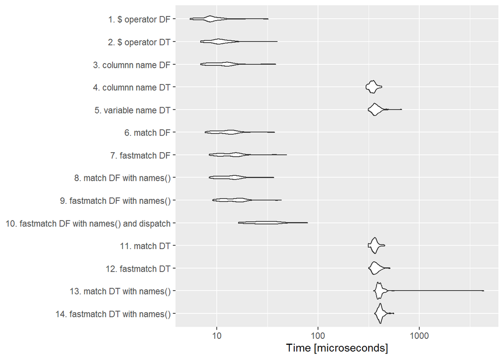

```
## Unit: microseconds
##  expr     min       lq      mean   median       uq      max neval  cld
##     1   5.499   7.8810   9.09415   8.7970   9.8970   32.255   100 a
##     2   6.964   9.1640  10.82055  10.2640  11.7300   39.586   100 a
##     3   6.964   8.7970  11.83582  11.7290  13.1955   38.120   100 a
##     4 297.624 329.1455 347.03218 346.7390 360.4835  427.010   100  b
##     5 312.285 352.0540 374.32416 364.8825 387.4235  667.087   100  bc
##     6   7.697   9.7135  13.01234  13.1960  14.2950   37.387   100 a
##     7   8.430  10.9960  14.67281  14.6615  15.7615   49.116   100 a
##     8   8.430  10.6300  13.95802  14.1120  15.3950   36.653   100 a
##     9   9.163  11.7290  15.69175  15.5780  17.0440   43.618   100 a
##    10  16.494  24.5580  31.03845  29.1395  37.5700   78.805   100 a
##    11 313.018 345.4560 363.37956 362.6830 374.5955  454.866   100  b
##    12 315.950 349.1210 374.07494 366.5320 388.5235  512.045   100  bc
##    13 354.069 388.5240 447.56440 405.9335 418.7630 4311.507   100    d
##    14 362.500 399.3365 416.50821 413.0810 426.2765  557.495   100   cd
```

The conclusion is that when using a data.frame or a data.table the **fastest method is the $ operator**. Beware that package resolution is a big burden on performance.

## Row selection

Evaluate the performance of different methods for row selection. Usually number of rows >> number of columns and thus the performance when selecting rows is a stronger limitation. In this case we will use as before two objects data.frame and data.table, but also combined with the library fastmatch.

1. Cell value comparison in a data.frame
2. Cell value comparison in a data.table
3. Row name match in a data.frame
4. Row name match in a data.table
5. Cell value native match in a data.frame
6. Cell value fastmatch in a data.frame
7. Cell value native match in a data.table
8. Cell value fastmatch in a data.table

```r
random_term <- get_random_term(raw_annotations)
column_values <- term2gene_df$Term
res <- microbenchmark(
    "1" = term2gene_df[term2gene_df$Term == random_term, ],
    "2" = term2gene_dt[term2gene_dt$Term == random_term, ],
    "3" = term2gene_df[random_term, ],
    "4" = term2gene_dt[random_term, ],
    "5" = term2gene_df[match(random_term, column_values), ],
    "6" = term2gene_df[fmatch(random_term, column_values), ],
    "7" = term2gene_dt[match(random_term, column_values), ],
    "8" = term2gene_dt[fmatch(random_term, column_values), ]
    )
```

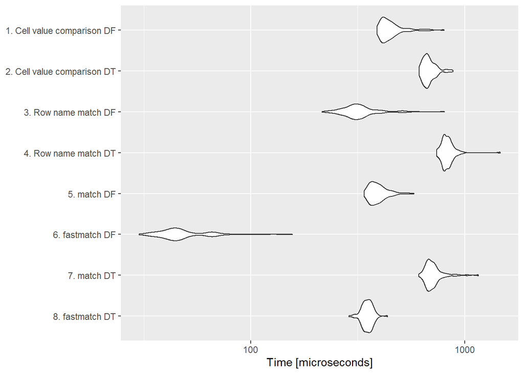

```
## Unit: microseconds
##  expr     min       lq      mean   median       uq      max neval     cld
##     1 389.990 411.4315 456.37222 435.2565 465.1285  803.070   100    d
##     2 613.940 646.9280 684.49385 672.2185 705.7560  884.074   100     e
##     3 215.888 287.5445 328.84131 313.0180 339.9575  806.369   100  b
##     4 739.661 796.4725 835.14181 826.7115 855.8505 1464.292   100       g
##     5 339.042 364.5160 395.90183 385.0415 412.5315  580.219   100   c
##     6  30.056  40.5020  49.01306  44.7170  51.1320  156.876   100 a
##     7 609.542 671.4860 715.31168 697.1425 730.3135 1160.072   100      f
##     8 288.094 337.2090 351.01647 351.1370 364.6990  436.172   100  b
```

## Intersection

Evaluate the performance of intersection between sets in a character vector.

1. Intersect using the %in% operator
2. Intersect using the intersect() function
3. Intersect using native match
4. Intersect using fastmatch

```r
res <- microbenchmark(
    "1" = first_set[first_set %in% second_set],
    "2" = intersect(first_set, second_set),
    "3" = first_set[!is.na(match(first_set, second_set))],
    "4" = first_set[!is.na(fmatch(first_set, second_set))]
)
```

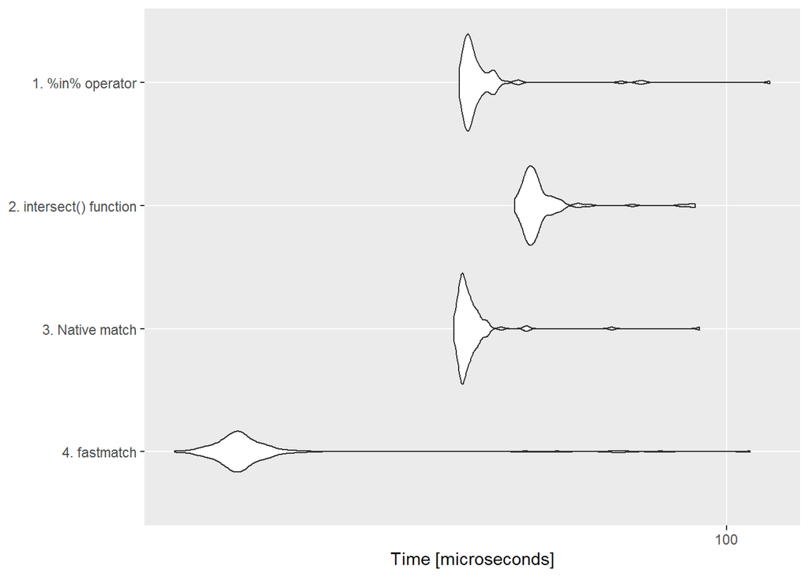

```
## Unit: microseconds
##  expr    min      lq     mean median     uq     max neval cld
##     1 38.487 39.5855 42.38255 39.953 41.602 116.924   100  b
##     2 46.916 49.1150 51.95256 50.215 51.681  89.434   100   c
##     3 37.753 38.8530 40.63421 39.220 40.502  90.900   100  b
##     4 13.929 16.8610 20.76455 17.594 18.693 108.860   100 a
```

The conclusion is that the **fastest intersection is provided by fastmatch**.

## Union

1. Union using the union() function
2. Union using the unique() function and concatenation
3. Union using native match
4. Union using fastmatch

```r
res <- microbenchmark(
    "1" = union(first_set, second_set),
    "2" = unique(c(first_set, second_set)),
    "3" = c(first_set, second_set[is.na(match(second_set, first_set))]),
    "4" = c(first_set, second_set[is.na(fmatch(second_set, first_set))])
)
```

[figure not shown]

```
## Unit: microseconds
##  expr    min     lq     mean median     uq     max neval cld
##     1 38.119 40.319 45.31474 41.785 44.351 113.626   100   c
##     2 35.187 36.654 40.84310 38.486 40.869  79.905   100  b
##     3 42.151 43.984 48.25069 45.450 47.283 135.617   100   c
##     4 16.495 19.427 22.74750 21.259 22.359  68.908   100 a
```

The conclusion is that the **fastest union is provided by fastmatch**.

## Difference

1. Difference using the %in% operator
2. Difference using the setdiff() function
3. Difference using native match
4. Difference using fastmatch

```r
res <- microbenchmark(
    "1" = first_set [! first_set %in% second_set],
    "2" = setdiff(first_set, second_set),
    "3" = first_set [is.na(match(first_set, second_set))],
    "4" = first_set [is.na(fmatch(first_set, second_set))]
)
```

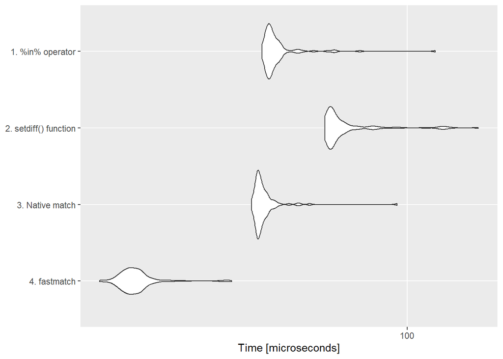

```
## Unit: microseconds
##  expr    min     lq     mean  median      uq     max neval cld
##     1 39.952 41.418 44.52673 42.1520 43.9840 119.490   100  b
##     2 59.379 61.211 69.41422 62.6775 67.2590 156.875   100   c
##     3 37.386 38.853 40.68183 39.4025 40.6855  93.832   100  b
##     4 14.295 16.861 18.15850 17.5940 18.6930  32.988   100 a
```

The conclusion is that the **fastest difference is provided by fastmatch**.

## XOR

1. XOR using the %in% operator (assuming intersection and union is already computed)
2. XOR using native match (assuming intersection and union is already computed)
3. XOR using native match alternative implementation
4. XOR using fastmatch (assuming intersection and union is already computed)
5. XOR using fastmatch alternative implementation

```r
union_set = c(first_set, second_set[is.na(fmatch(second_set, first_set))])
intersection_set = first_set[!is.na(fmatch(first_set, second_set))]
res <- microbenchmark(
    "1" = union_set[!union_set %in% intersection_set],
    "2" = union_set[is.na(match(union_set, intersection_set))],
    "3" = c(first_set[is.na(match(first_set, second_set))],
                        second_set[is.na(match(second_set, first_set))]),
    "4" = union_set[is.na(fmatch(union_set, intersection_set))],
    "5" = c(first_set[is.na(fmatch(first_set, second_set))],
                        second_set[is.na(fmatch(second_set, first_set))])
)
```

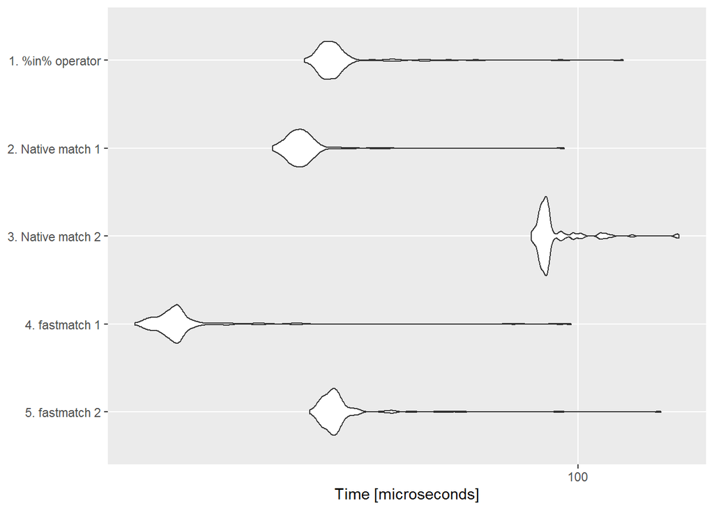

```
## Unit: microseconds
##  expr    min     lq     mean  median      uq     max neval  cld
##     1 35.921 38.486 41.99766 39.7690 41.0515 118.390   100   c
##     2 31.889 34.088 36.17349 35.3705 36.2875  94.932   100  b
##     3 83.936 87.235 91.80928 88.7010 89.8010 145.880   100    d
##     4 19.060 21.259 24.41885 21.9930 22.7250  97.497   100 a
##     5 36.654 38.853 42.45216 39.9520 41.0520 136.350   100   c
```

The conclusion is that the **fastest union is provided by fastmatch**. If intersection and union are already computed use the first version, otherwise use the alternative implementation.

## Compiling function to byte code

The just-in-time compilation allows that the code of our R code is translated into byte code and save some interpretation time at execution time. Our implementation is based on the compiler package included in base R.

```r
get_ui_similarity_bc <- compiler::cmpfun(get_ui_similarity)
```

When benchmarking the execution time of several JIT compiled functions with their plain R counterparts we observe a slight increase in performance.

```r
random_term_1 <- get_random_term(raw_annotations)
random_term_2 <- get_random_term(raw_annotations)
kegg <- TCGAome::load_kegg()
```

```
## INFO [2016-09-22 21:53:50] Loading human KEGG...
## INFO [2016-09-22 21:53:51] Loaded 229 KEGG pathways and 5869 genes
```

```r
res <- microbenchmark(
    "1" = get_cosine_similarity(kegg, random_term_1, random_term_2),
    "2" = get_cosine_similarity_bc(kegg, random_term_1, random_term_2),
    "3" = get_binary_similarity(kegg, random_term_1, random_term_2),
    "4" = get_binary_similarity_bc(kegg, random_term_1, random_term_2),
    "5" = get_bc_similarity(kegg, random_term_1, random_term_2),
    "6" = get_bc_similarity_bc(kegg, random_term_1, random_term_2),
    "7" = get_ui_similarity(kegg, random_term_1, random_term_2),
    "8" = get_ui_similarity_bc(kegg, random_term_1, random_term_2)
)
```

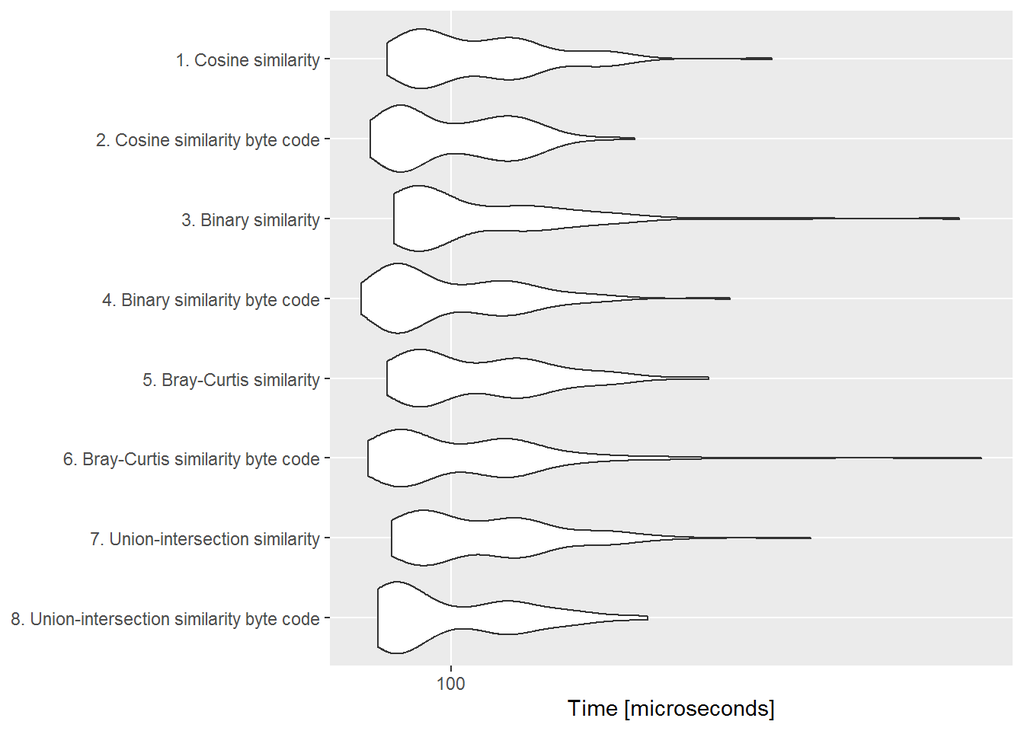

```
## Unit: microseconds
##  expr    min      lq     mean   median       uq     max neval cld
##     1 89.068 94.5650 105.9610 103.3620 113.2580 177.768   100   a
##     2 86.502 91.2660 101.0239  98.2310 110.3265 138.916   100   a
##     3 90.168 93.4660 106.4814  96.3980 114.5410 248.875   100   a
##     4 85.036 90.1670 100.6060  94.9325 109.5935 164.939   100   a
##     5 89.067 94.0160 106.4595 102.4460 113.8085 158.709   100   a
##     6 86.135 90.9005 104.2750  97.4970 110.6930 259.138   100   a
##     7 89.800 94.9325 107.1340 102.4465 113.8090 190.597   100   a
##     8 87.601 90.1670 100.8589  94.3820 110.8760 142.214   100   a
```